# The One-Dimensional Quantum Harmonic Oscillator

Author

Daniel Fischer

# Introduction

The **harmonic oscillator** is one of the most fundamental problems in physics. It appears not only in **quantum mechanics**, but also in **molecular vibrations**, **phonons**, **field quantization**, and even **quantum information theory**.

Its importance stems from the fact that **any potential** that is smooth near its equilibrium point can be approximated as quadratic — and hence locally behaves like a harmonic oscillator.

There are several ways to solve the Schrödinger equation for the harmonic oscillator:

- The **differential equation method**, which solves the Schrödinger equation directly in coordinate space.
- The **algebraic (operator) method**, which uses **creation and annihilation operators** to derive energies and wavefunctions in a more elegant, general, and physically transparent way.

In this chapter, we focus on the **algebraic method**, which introduces concepts that are also crucial in:  
- the **quantization of the electromagnetic field**,  
- **angular momentum algebra**, and  
- **many-body quantum theory**.

# 1. The Hamiltonian, Ladder , and Number Operators

The one-dimensional harmonic oscillator describes a particle of mass $m$ moving in a quadratic potential:

$$\hat{H} = \frac{\hat{p}^2}{2m} + \frac{1}{2} m \omega^2 \hat{x}^2.$$

Here, $\hat{x}$ and $\hat{p}$ are the position and momentum operators, satisfying the **canonical commutation relation**:

$$[\hat{x}, \hat{p}] = i\hbar.$$

## 1.1 The Ladder Operators

To simplify the algebra, we introduce **ladder operators** (also called **annihilation** and **creation** operators):

$$\hat{a} = \sqrt{\frac{m\omega}{2\hbar}}\,\hat{x} + \frac{i}{\sqrt{2m\hbar\omega}}\,\hat{p}, \qquad
\hat{a}^\dagger = \sqrt{\frac{m\omega}{2\hbar}}\,\hat{x} - \frac{i}{\sqrt{2m\hbar\omega}}\,\hat{p}.$$

Note that $\hat{a}$ and $\hat{a}^\dagger$ are Hermitian conjugates of each other. They satisfy the simple commutation relation (easily derived from the canonical commutator):

$$[\hat{a}, \hat{a}^\dagger] = 1.$$

The Hamiltonian can now be rewritten in a remarkably compact form:

$$\hat{H} = \hbar \omega \left( \hat{a}^\dagger \hat{a} + \frac{1}{2} \right).$$

**NoteDerivation sketch**

Starting from the definition of $\hat{a}$ and $\hat{a}^\dagger$, you can show that:

$$\hat{a}^\dagger \hat{a} = \frac{m\omega}{2\hbar}\hat{x}^2 + \frac{1}{2m\hbar\omega}\hat{p}^2 - \frac{i}{2\hbar}(\hat{x}\hat{p}-\hat{p}\hat{x})
= \frac{1}{2\hbar\omega}\left(\frac{\hat{p}^2}{m} + m\omega^2 \hat{x}^2\right) - \frac{1}{2}.$$

Rearranging gives:
$$\hat{H} = \hbar\omega\left(\hat{a}^\dagger \hat{a} + \frac{1}{2}\right).$$

The operators $\hat{a}^\dagger$ and $\hat{a}$ act as **raising** and **lowering** operators on energy eigenstates. To demonstrate explicitly how they raise and lower energy eigenstates, we compute the commutator (using $[\hat{a},\hat{a}^\dagger]=1$):
$$\begin{aligned}
\left[ \hat{H}, \hat{a}^\dagger \right]
&=\hbar\omega\big[\hat{a}^\dagger\hat{a}+\tfrac{1}{2},\hat{a}^\dagger\big] \\
&=\hbar\omega\big(\hat{a}^\dagger[\hat{a},\hat{a}^\dagger]+[\hat{a}^\dagger,\hat{a}^\dagger]\hat{a}\big) \\
&=\hbar\omega\,\hat{a}^\dagger\cdot 1 \;=\; \hbar\omega\,\hat{a}^\dagger.
\end{aligned}$$

We can now use this commutator to move $\hat{H}$ past $\hat{a}^\dagger$ when acting on an energy eigenstate $|n\rangle$ with $\hat H|n\rangle=E_n|n\rangle$:

$$\begin{aligned}
\hat{H}\big(\hat{a}^\dagger|n\rangle\big)
&=\big([\hat{H},\hat{a}^\dagger]+\hat{a}^\dagger\hat{H}\big)|n\rangle \\
&=(\hbar\omega\,\hat{a}^\dagger+\hat{a}^\dagger E_n)|n\rangle \\
&=(E_n+\hbar\omega)\,\hat{a}^\dagger|n\rangle.
\end{aligned}
\tag{1}$$

Thus, $\hat{a}^\dagger|n\rangle$ is an eigenvector of $\hat{H}$ with energy $E_n + \hbar\omega$. We therefore label this higher-lying state as $|n+1\rangle$, such that
$$\hat{a}^\dagger|n\rangle \propto |n+1\rangle.$$

In the same way, using the commutator $[\hat{H}, \hat{a}] = -\hbar\omega \hat{a}$, we obtain
$$\hat{H}\big(\hat{a}|n\rangle\big)=(E_n-\hbar\omega)\,\hat{a}|n\rangle,
\tag{2}$$
which shows that $\hat{a}|n\rangle$ is an eigenstate with lower energy. We label this state $|n-1\rangle$,
$$\hat a|n\rangle\propto |n-1\rangle.$$

As we will see below, with proper normalization we obtain

$$\hat{a}^\dagger|n\rangle = \sqrt{n+1}\, |n+1\rangle ,
\tag{3}$$

and similarly,
$$\hat a|n\rangle= \sqrt{n}\, |n-1\rangle \qquad(n\ge1).
\tag{4}$$

## 1.2 The Number Operator

We introduce the **number operator**

$$\hat{N} = \hat{a}^\dagger \hat{a}.$$

We will now **prove** that $\hat{N}$ acts as a counting operator, that is,
$$\hat{N}|n\rangle = n\,|n\rangle,$$
for all nonnegative integers $n$.

### Proof (by induction)

**Base case:**  
Since energy cannot be negative, there must exist a lowest-energy state $|0\rangle$ (the **ground state**) such that:

$$\hat{a}|0\rangle = 0.$$
Applying $\hat{N}$ gives
$$\hat{N}|0\rangle = \hat{a}^\dagger \hat{a}|0\rangle = 0,$$
so the statement is true for $n=0$.

**Induction hypothesis:**  
Assume $\hat{N}|n\rangle = n|n\rangle$ holds for some $n$.

**Induction step:**
Using the commutation relation $[\hat{N}, \hat{a}^\dagger] = \hat{a}^\dagger\, \hat{a}\, \hat{a}^\dagger\, -\, \hat{a}^\dagger\, \hat{a}^\dagger\, \hat{a} = \hat{a}^\dagger [\hat{a}, \hat{a}^\dagger] = \hat{a}^\dagger$, we find
$$\begin{aligned}
\hat{N}(\hat{a}^\dagger|n\rangle)
&= (\hat{a}^\dagger \hat{N} + [\hat{N}, \hat{a}^\dagger])|n\rangle \\
&= n\,\hat{a}^\dagger|n\rangle + \hat{a}^\dagger|n\rangle \\
&= (n+1)\,\hat{a}^\dagger|n\rangle.
\end{aligned}$$
Thus, if the statement holds for $n$, it also holds for $n+1$.
By mathematical induction, $\hat{N}|n\rangle = n|n\rangle$ for all $n$.

### Determining the normalization factors of the ladder operators

To determine the correct normalization constants stated in Equation 3 and Equation 4, we now use the number operator.

1. **Unnormalized definition**

   We know that $\hat a^\dagger$ raises the state:
   $$\hat a^\dagger |n\rangle = C_{n+1}\,|n+1\rangle.$$
2. **Take the inner product**

   $$\langle n| \hat a \hat a^\dagger |n\rangle = |C_{n+1}|^2.$$
3. **Use the commutation relation**

   Since $\hat a \hat a^\dagger = \hat a^\dagger \hat a + [ \hat a, \hat a^\dagger] = \hat a^\dagger \hat a + 1 = \hat N + 1$,
   $$|C_{n+1}|^2 = \langle n|(\hat N + 1)|n\rangle = n + 1.$$
4. **Extract the constant**

   $$C_{n+1} = \sqrt{n+1}.$$

Hence,
$$\hat a^\dagger |n\rangle = \sqrt{n+1}\,|n+1\rangle,$$
and similarly,
$$\hat a |n\rangle = \sqrt{n}\,|n-1\rangle.$$

# 2. Energy Eigenvalues

Let $|n\rangle$ be an energy eigenstate of the oscillator, defined by:

$$\hat{H}|n\rangle = E_n |n\rangle.$$

First consider the **lowest-energy state** $|0\rangle$ (the **ground state**), which satisfies

$$\hat{a}|0\rangle = 0.$$

Applying the Hamiltonian yields:

$$\hat{H}|0\rangle = \hbar \omega \left( \hat{a}^\dagger \hat{a} + \frac{1}{2} \right)|0\rangle = \frac{1}{2}\hbar\omega\,|0\rangle.$$

Hence, the **ground-state energy** is:

$$E_0 = \frac{1}{2}\hbar\omega.$$

We have already seen that the operator $\hat{a}^\dagger$ *raises* the energy (cf. Equation 1):

$$\hat{H}(\hat{a}^\dagger|n\rangle) = (E_n + \hbar\omega)(\hat{a}^\dagger|n\rangle),$$

Therefore, each application of $\hat{a}^\dagger$ increases the energy by one quantum $\hbar\omega$, leading to the complete **energy spectrum**:

$$E_n = \hbar\omega\left(n + \frac{1}{2}\right), \qquad n = 0, 1, 2, \ldots$$

**NoteWhy is this the **complete** spectrum?**

A natural question arises: could there be “hidden” energy eigenstates between the levels we’ve constructed? The answer is no, and here’s why:

Suppose $|\psi\rangle$ is *any* energy eigenstate with energy $E$. Since $\hat{H} = \hbar\omega(\hat{N} + \frac{1}{2})$, we have:
$$\hat{N}|\psi\rangle = \left(\frac{E}{\hbar\omega} - \frac{1}{2}\right)|\psi\rangle \equiv \lambda\, |\psi\rangle.$$

The eigenvalue $\lambda$ must satisfy two constraints:

1. **Non-negativity**: Since $\hat{N} = \hat{a}^\dagger \hat{a}$, we have $\langle \psi | \hat{N} | \psi \rangle = \|\hat{a}|\psi\rangle\|^2 \geq 0$, so $\lambda \geq 0$.
2. **Integrality**: Repeatedly applying $\hat{a}$ decreases the eigenvalue by 1 each time (since $[\hat{N}, \hat{a}] = -\hat{a}$). This process must terminate at the ground state where $\hat{a}|0\rangle = 0$. Since we cannot have negative eigenvalues, $\lambda$ must be a nonnegative integer.

Therefore, every energy eigenstate must correspond to $\hat{N}$ eigenvalue $n \in \{0, 1, 2, \ldots\}$, and we’ve already constructed all such states. The spectrum is complete—no intermediate energies exist.

# 3. Finding the Wavefunctions

To find the explicit forms of the wavefunctions, we can apply the lowering operator definition to the coordinate representation.

In position space, the ground state $|0\rangle$ satisfies:

$$\hat{a}\psi_0(x) = 0.$$

Using

$$\hat{p} = -i\hbar \frac{d}{dx},$$

this condition becomes:

$$\left(\sqrt{\frac{m\omega}{2\hbar}}\,x + \frac{\hbar}{\sqrt{2m\hbar\omega}}\frac{d}{dx}\right)\psi_0(x) = 0.$$

Solving gives:

$$\psi_0(x) = A_0\, e^{-\frac{m\omega x^2}{2\hbar}},$$

where $A_0 = \left(\frac{m\omega}{\pi\hbar}\right)^{1/4}$ ensures normalization.

Higher-order states are obtained by applying $\hat{a}^\dagger$ repeatedly:

$$\psi_n(x) = \frac{1}{\sqrt{n!}}\left(\hat{a}^\dagger\right)^n \psi_0(x),$$

which leads to the standard Hermite polynomial form:

$$\psi_n(x) =
\frac{1}{\sqrt{2^n n!}}
\left(\frac{m\omega}{\pi\hbar}\right)^{1/4}
H_n\!\left(\sqrt{\frac{m\omega}{\hbar}}\,x\right)
e^{-\frac{m\omega x^2}{2\hbar}}.$$

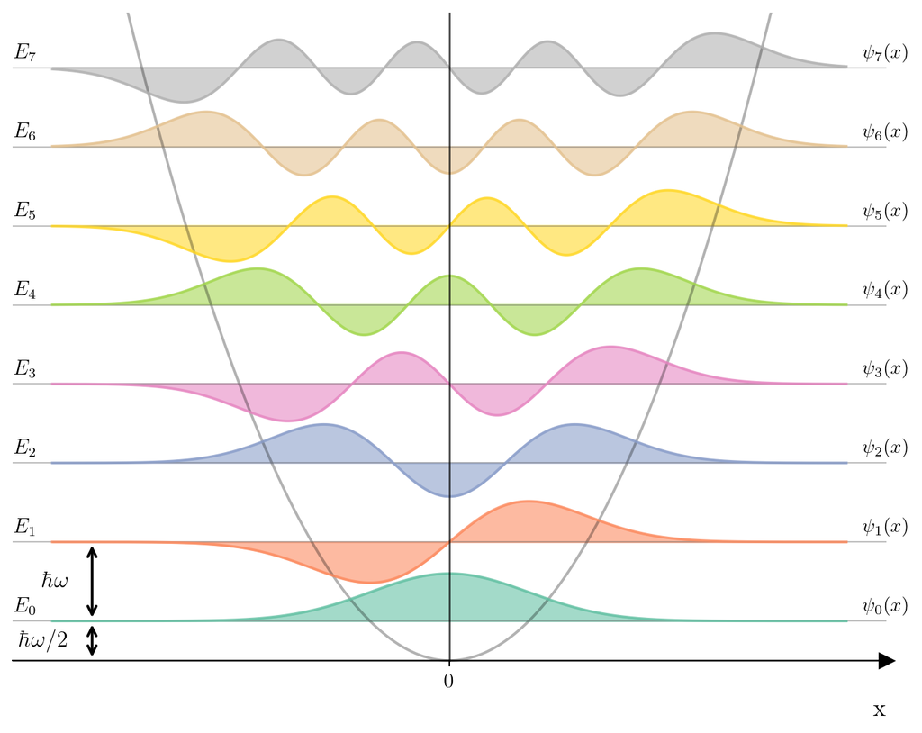

```python
import numpy as np
import matplotlib.pyplot as plt
from scipy.special import hermite
from scipy.special import factorial

# --- Set up plot styling ---
plt.rcParams['text.usetex'] = True
plt.rcParams['font.family'] = 'serif'
plt.rcParams['font.size'] = 12


# Parameters
m = 1.0  # mass
omega = 1.0  # angular frequency
hbar = 1.0  # reduced Planck constant
x = np.linspace(-5, 5, 1000)

# Harmonic oscillator potential
V = 0.5 * m * omega**2 * x**2

# Wavefunction for the n-th energy level
def psi_n(n, x, m=1.0, omega=1.0, hbar=1.0):
    """Calculate the n-th energy eigenstate wavefunction"""
    alpha = np.sqrt(m * omega / hbar)
    normalization = (alpha / np.pi)**0.25 / np.sqrt(2**n * factorial(n))
    H_n = hermite(n)
    return normalization * np.exp(-alpha**2 * x**2 / 2) * H_n(alpha * x)

# Energy levels
def E_n(n, omega=1.0, hbar=1.0):
    """Energy of the n-th level"""
    return hbar * omega * (n + 0.5)

# Create figure
fig, ax = plt.subplots(figsize=(7.5, 6))

# Plot potential
ax.plot(x, V, 'k-', linewidth=1.5, alpha=0.3, label='Potential V(x)')

# Number of levels to plot
n_levels = 8
colors = plt.cm.Set2(np.linspace(0, 1, n_levels))

# Plot energy levels and wavefunctions
scale = 0.8  # scale factor for wavefunction amplitude

for n in range(n_levels):
    E = E_n(n, omega, hbar)

    # Plot energy level line
    ax.axhline(y=E, color='gray', linestyle='-', linewidth=0.8, alpha=0.5)

    # Calculate and plot wavefunction
    psi = psi_n(n, x, m, omega, hbar)

    # Scale and shift wavefunction to sit on energy level
    psi_scaled = scale * psi + E

    # Fill the wavefunction with color
    ax.fill_between(x, E, psi_scaled, alpha=0.6, color=colors[n],
                     where=(psi_scaled >= E), interpolate=True)
    ax.fill_between(x, E, psi_scaled, alpha=0.6, color=colors[n],
                     where=(psi_scaled < E), interpolate=True)

    # Plot the wavefunction line
    ax.plot(x, psi_scaled, color=colors[n], linewidth=1.5, alpha=0.8)

    # Add energy level labels
    ax.text(-5.2, E+0.07, f'$E_{n}$', fontsize=12, va='bottom', ha='right')

    # Add wavefunction labels
    ax.text(5.2, E+0.07, f'$\\psi_{n}(x)$', fontsize=11, va='bottom', ha='left')

# Add energy spacing annotation
E0 = E_n(0, omega, hbar)
E1 = E_n(1, omega, hbar)
ax.annotate('', xy=(-4.5, E1), xytext=(-4.5, E0),
            arrowprops=dict(arrowstyle='<->', color='black', lw=1.5))
ax.text(-4.8, (E0 + E1)/2, r'$\hbar\omega$', fontsize=13, va='center', ha='right')

# Add half energy spacing annotation
ax.annotate('', xy=(-4.5, E0), xytext=(-4.5, 0),
            arrowprops=dict(arrowstyle='<->', color='black', lw=1.5))
ax.text(-4.8, E0/2, r'$\hbar\omega/2$', fontsize=13, va='center', ha='right')

# Vertical axis at x=0
ax.plot([0,0], [0,E_n(n_levels-1) + 0.7], color='black', linewidth=1, alpha=0.7)

# Horizontal axis
ax.axhline(y=0, color='black', linewidth=1.0, alpha=0.5)

# Formatting
ax.set_xlim(-5.5, 5.5)
ax.set_ylim(-0.5, E_n(n_levels-1) + 0.7)
ax.set_xlabel('x', fontsize=14, loc='right')
#ax.set_ylabel('$\\psi(x)$', fontsize=14, loc='top', rotation=0)
ax.yaxis.set_label_coords(0.02, 0.98)

# Remove ticks
ax.set_xticks([0])
ax.set_yticks([])
ax.spines['top'].set_visible(False)
ax.spines['right'].set_visible(False)
ax.spines['left'].set_visible(False)
ax.spines['bottom'].set_position('zero')

# Add arrow to x-axis
ax.plot(1, 0, ">k", transform=ax.get_yaxis_transform(), clip_on=False, markersize=8)

# Title
#ax.set_title('Quantum Harmonic Oscillator: Energy Levels and Wavefunctions',
#             fontsize=14, pad=20, fontweight='bold')

plt.tight_layout()
plt.show()
```

# 4. Coherent States

Although our focus is the stationary states of the harmonic oscillator, there exists a special class of **non-stationary states** — the **coherent states** — that behave most like classical oscillations.

A **coherent state** $|\alpha\rangle$ is defined as the **eigenstate** of the annihilation operator:

$$\hat{a}|\alpha\rangle = \alpha|\alpha\rangle,$$

where $\alpha$ is a complex number. Its wavefunction in position space is a **displaced Gaussian** that oscillates without changing shape.

In the energy basis, it can be expanded as:

$$|\alpha\rangle = e^{-|\alpha|^2/2}\sum_{n=0}^\infty \frac{\alpha^n}{\sqrt{n!}}|n\rangle.$$

The expectation values of position and momentum evolve as:

$$\langle \hat{x}(t) \rangle = \sqrt{\frac{2\hbar}{m\omega}}\;\text{Re}\big[\alpha e^{-i\omega t}\big],$$
$$\langle \hat{p}(t) \rangle = \sqrt{2m\hbar\omega}\;\text{Im}\big[\alpha e^{-i\omega t}\big],$$

showing that the **center of the wave packet** oscillates just like a **classical particle**.

The following animation illustrates the structure and dynamics of a coherent state. Each stationary wavefunction $\psi_n(x)$ is plotted at its corresponding energy level $E_n$, scaled according to the coefficient $|c_n| = e^{-|\alpha|^2/2} |\alpha|^n / \sqrt{n!}$ appearing in the coherent-state superposition. The red curve represents the **time-dependent probability density** $|\psi_\alpha(x, t)|^2$ of the coherent state, which oscillates back and forth in the harmonic potential without changing shape — a uniquely quantum realization of a classical oscillation.

```python
import numpy as np
import matplotlib.pyplot as plt
from scipy.special import hermite
from scipy.special import factorial
from matplotlib.animation import FuncAnimation
from IPython.display import HTML


# --- Set up plot styling ---
plt.rcParams['text.usetex'] = True
plt.rcParams['font.family'] = 'serif'
plt.rcParams['font.size'] = 12


# Parameters
m = 1.0  # mass
omega = 1.0  # angular frequency
hbar = 1.0  # reduced Planck constant
x = np.linspace(-5, 5, 1000)

# Harmonic oscillator potential
V = 0.5 * m * omega**2 * x**2

# Wavefunction for the n-th energy level
def psi_n(n, x, m=1.0, omega=1.0, hbar=1.0):
    """Calculate the n-th energy eigenstate wavefunction"""
    alpha = np.sqrt(m * omega / hbar)
    normalization = (alpha / np.pi)**0.25 / np.sqrt(2**n * factorial(n))
    H_n = hermite(n)
    return normalization * np.exp(-alpha**2 * x**2 / 2) * H_n(alpha * x)

# Energy levels
def E_n(n, omega=1.0, hbar=1.0):
    """Energy of the n-th level"""
    return hbar * omega * (n + 0.5)

# Coherent state coefficients
def coherent_state_coeff(n, alpha):
    """Coefficient c_n for coherent state |alpha>"""
    return np.exp(-abs(alpha)**2 / 2) * alpha**n / np.sqrt(factorial(n))

# Coherent state wavefunction
def coherent_state_psi(x, alpha, t, n_max=30, m=1.0, omega=1.0, hbar=1.0):
    """Time-dependent coherent state wavefunction"""
    psi = np.zeros_like(x, dtype=complex)
    for n in range(n_max):
        c_n = coherent_state_coeff(n, alpha)
        E = E_n(n, omega, hbar)
        phase = np.exp(-1j * E * t / hbar)
        psi += c_n * psi_n(n, x, m, omega, hbar) * phase
    return psi

# Find alpha for desired coherent state energy
def find_alpha_for_energy(E_coh, omega=1.0, hbar=1.0):
    """Find alpha such that <E> = E_coh"""
    # For coherent state: <E> = hbar*omega*(|alpha|^2 + 1/2)
    # E_coh = hbar*omega*(|alpha|^2 + 1/2)
    # |alpha|^2 = E_coh/(hbar*omega) - 1/2
    alpha_squared = E_coh / (hbar * omega) - 0.5
    return np.sqrt(max(0, alpha_squared))

# Setup
n_levels = 8
E_coh = (E_n(0) + E_n(3)) / 2  # Energy between E_0 and E_7
alpha = find_alpha_for_energy(E_coh, omega, hbar)

#print(f"Coherent state energy: E_coh = {E_coh:.2f}")
#print(f"Alpha parameter: α = {alpha:.2f}")
#print(f"Average quantum number: <n> = |α|² = {alpha**2:.2f}")

# Create figure
fig, ax = plt.subplots(figsize=(7.5, 6))

# Plot potential
ax.plot(x, V, 'k-', linewidth=1.5, alpha=0.3)

# Colors for eigenstates
colors = plt.cm.Set2(np.linspace(0, 1, n_levels))

# Plot energy levels and scaled wavefunctions
scale = 0.3
eigenstate_plots = []

for n in range(n_levels):
    E = E_n(n, omega, hbar)

    # Plot energy level line
    ax.axhline(y=E, color='gray', linestyle='-', linewidth=0.8, alpha=0.5)

    # Calculate wavefunction and coherent state coefficient
    psi = psi_n(n, x, m, omega, hbar)
    c_n = coherent_state_coeff(n, alpha)

    # Scale by coherent state coefficient (use absolute value for scaling)
    scaling_factor = abs(c_n) * 5  # Extra factor for visibility
    psi_scaled = scale * scaling_factor * psi + E

    # Fill and plot
    fill = ax.fill_between(x, E, psi_scaled, alpha=0.6, color=colors[n])
    line, = ax.plot(x, psi_scaled, color=colors[n], linewidth=1.5, alpha=0.8)

    eigenstate_plots.append((fill, line))

    # Add energy level labels
    ax.text(-5.2, E+0.07, f'$E_{n}$', fontsize=12, va='bottom', ha='right')

    # Add wavefunction labels
    ax.text(5.2, E+0.07, f'$\\psi_{n}(x)$', fontsize=11, va='bottom', ha='left')

# Add energy spacing annotations
E0 = E_n(0, omega, hbar)
E1 = E_n(1, omega, hbar)
ax.annotate('', xy=(-4.5, E1), xytext=(-4.5, E0),
            arrowprops=dict(arrowstyle='<->', color='black', lw=1.5))
ax.text(-4.8, (E0 + E1)/2, r'$\hbar\omega$', fontsize=13, va='center', ha='right')

ax.annotate('', xy=(-4.5, E0), xytext=(-4.5, 0),
            arrowprops=dict(arrowstyle='<->', color='black', lw=1.5))
ax.text(-4.8, E0/2, r'$\hbar\omega/2$', fontsize=13, va='center', ha='right')

# Mark coherent state energy level
ax.axhline(y=E_coh, color='red', linestyle='--', linewidth=0.5, alpha=0.7)
ax.text(-5.2, E_coh+0.07, r'$E_{{coh}}=\langle \hat H \rangle$', fontsize=12, va='bottom', ha='right', color='red')

# Initialize coherent state plot
coh_scale = 3  # Scale for coherent state probability density
psi_coh_t0 = coherent_state_psi(x, alpha, 0, n_max=30, m=m, omega=omega, hbar=hbar)
prob_density = np.abs(psi_coh_t0)**2
prob_scaled = coh_scale * prob_density + E_coh

coherent_fill = ax.fill_between(x, E_coh, prob_scaled, alpha=0.7, color='red', label='Coherent state')
coherent_line, = ax.plot(x, prob_scaled, 'r-', linewidth=2, alpha=0.9)

# Axes formatting
ax.plot([0,0], [0,E_n(n_levels-1) + 0.7], color='black', linewidth=1, alpha=0.7)
ax.axhline(y=0, color='black', linewidth=1.0, alpha=0.5)

ax.set_xlim(-5.5, 5.5)
ax.set_ylim(-0.5, E_n(n_levels-1) + 0.7)
ax.set_xlabel('x', fontsize=14, loc='right')
#ax.set_ylabel('$\\psi(x)$', fontsize=14, loc='top', rotation=0)
ax.yaxis.set_label_coords(0.02, 0.98)

ax.set_xticks([0])
ax.set_yticks([])
ax.spines['top'].set_visible(False)
ax.spines['right'].set_visible(False)
ax.spines['left'].set_visible(False)
ax.spines['bottom'].set_position('zero')

ax.plot(1, 0, ">k", transform=ax.get_yaxis_transform(), clip_on=False, markersize=8)

time_text = ax.text(0.02, 1, '', transform=ax.transAxes, fontsize=12,
                    verticalalignment='top', bbox=dict(boxstyle='round', facecolor='wheat', alpha=0.5))

#ax.set_title('Quantum Harmonic Oscillator: Coherent State Evolution',
#             fontsize=14, pad=20, fontweight='bold')

# Animation
def animate(frame):
    t = frame  # Time step
    # Update coherent state
    psi_coh = coherent_state_psi(x, alpha, t, n_max=30, m=m, omega=omega, hbar=hbar)
    prob_density = np.abs(psi_coh)**2
    prob_scaled = coh_scale * prob_density + E_coh

    # Update coherent state plot
    coherent_line.set_ydata(prob_scaled)

    # Update fill
    global coherent_fill
    coherent_fill.remove()
    coherent_fill = ax.fill_between(x, E_coh, prob_scaled, alpha=0.7, color='red')

    # Update time text
    time_text.set_text(f't = {t:.1f}')

    return coherent_line, time_text


t_max = 37.8
frames = [i * 0.2 for i in range(int(t_max/0.2)+1)]
anim = FuncAnimation(fig, animate, frames=frames, interval=50, blit=False)

plt.tight_layout()
plt.close()

# Display as HTML5 video in Jupyter
HTML(anim.to_html5_video())
```

[video not shown]

Coherent states thus form a conceptual bridge between **quantum** and **classical mechanics**, and they play a crucial role in **quantum optics** and **field theory**.

# Key Takeaways

- The **algebraic method** provides an elegant and general solution to the harmonic oscillator problem.
- **Ladder operators** simplify the derivation of the entire energy spectrum.
- The **ground-state wavefunction** is a Gaussian, and higher states are obtained using Hermite polynomials.
- **Coherent states** link quantum oscillations to classical motion.